# Tugas Praktikum MPDW | Pemodelan ARIMA Harga Penutupan Saham BBCA

# Pendahuluan dan Data

Praktikum ini memodelkan **harga penutupan (*Close*) harian saham BBCA** dengan metode ARIMA mengikuti delapan tahapan Box-Jenkins:

1. Pembagian data latih dan data uji
2. Pemeriksaan kestasioneran data latih (rataan dan ragam)
3. Penanganan ketidakstasioneran (diferensiasi / transformasi)
4. Identifikasi model potensial (ACF, PACF, EACF)
5. Pendugaan parameter: uji signifikansi dan AIC
6. Analisis sisaan
7. Overfitting
8. Peramalan

```r
bbca <- read.csv("C:\\Users\\syari\\Downloads\\BBCA_Historical_Data_3_Tahun_2023_2026.csv")
bbca$Date <- as.Date(bbca$Date)
bbca <- bbca[order(bbca$Date), ]

n_total <- nrow(bbca)
kable(head(bbca, 5), caption = "Lima baris pertama data")
```

Lima baris pertama data

| Date | Open | High | Low | Close | Adj.Close | Volume |
| --- | --- | --- | --- | --- | --- | --- |
| 2023-08-28 | 9168.0 | 9239.6 | 9121.3 | 9152.6 | 9152.6 | 37686426 |
| 2023-08-29 | 9171.1 | 9195.3 | 9079.0 | 9141.4 | 9141.4 | 114226714 |
| 2023-08-30 | 9232.6 | 9269.3 | 9153.8 | 9209.6 | 9209.6 | 35340110 |
| 2023-08-31 | 9380.9 | 9439.7 | 9355.7 | 9368.0 | 9368.0 | 112307454 |
| 2023-09-01 | 9344.7 | 9360.4 | 9327.4 | 9346.7 | 9346.7 | 26240327 |

```r
data.frame(
  Jumlah_amatan  = n_total,
  Data_hilang    = sum(is.na(bbca)),
  Tanggal_awal   = format(min(bbca$Date)),
  Tanggal_akhir  = format(max(bbca$Date)),
  Close_min      = min(bbca$Close),
  Close_maks     = max(bbca$Close)
)
```

```
##   Jumlah_amatan Data_hilang Tanggal_awal Tanggal_akhir Close_min Close_maks
## 1           784           0   2023-08-28    2026-08-27    8092.8      12292
```

Data terdiri dari **784 amatan** tanpa nilai hilang. Data hanya memuat hari bursa, sehingga amatan diperlakukan sebagai deret waktu berurutan (tanpa musiman kalender).

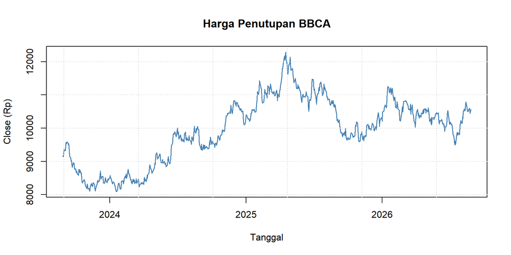

```r
plot(bbca$Date, bbca$Close, type = "l", col = "steelblue", lwd = 1.5,
     xlab = "Tanggal", ylab = "Close (Rp)", main = "Harga Penutupan BBCA")
grid()
```

# Pembagian Data Latih dan Data Uji

Data dibagi **90% latih : 10% uji**. Proporsi ini dipilih karena: (i) model ARIMA membutuhkan data latih yang panjang agar pendugaan parameter stabil dan (ii) data uji sekitar satu kuartal bursa sudah cukup untuk menilai peramalan jangka menengah, sementara peramalan yang terlalu jauh pada deret mirip *random walk* akan sangat melebar tanpa menambah informasi.

```r
prop_train <- 0.90
n_train <- floor(prop_train * n_total)

train_df <- bbca[1:n_train, ]
test_df  <- bbca[(n_train + 1):n_total, ]

train <- ts(train_df$Close)
test  <- test_df$Close

data.frame(
  Bagian = c("Latih", "Uji"),
  Amatan = c(nrow(train_df), nrow(test_df)),
  Dari   = c(format(min(train_df$Date)), format(min(test_df$Date))),
  Sampai = c(format(max(train_df$Date)), format(max(test_df$Date)))
)
```

```
##   Bagian Amatan       Dari     Sampai
## 1  Latih    705 2023-08-28 2026-05-08
## 2    Uji     79 2026-05-11 2026-08-27
```

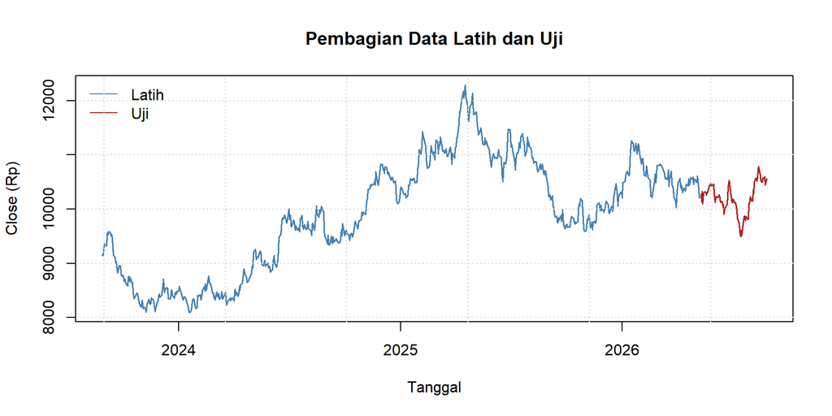

```r
plot(train_df$Date, train_df$Close, type = "l", col = "steelblue", lwd = 1.5,
     xlim = range(bbca$Date), ylim = range(bbca$Close),
     xlab = "Tanggal", ylab = "Close (Rp)", main = "Pembagian Data Latih dan Uji")
lines(test_df$Date, test_df$Close, col = "firebrick", lwd = 1.5)
legend("topleft", legend = c("Latih", "Uji"), col = c("steelblue", "firebrick"),
       lty = 1, bty = "n")
grid()
```

# Kestasioneran Data Latih

## Kestasioneran dalam Rataan

Pemeriksaan menggunakan plot deret waktu, plot ACF, dan uji *Augmented Dickey-Fuller* (ADF) dengan hipotesis:

- $H_0$: data tidak stasioner (memiliki akar unit)
- $H_1$: data stasioner

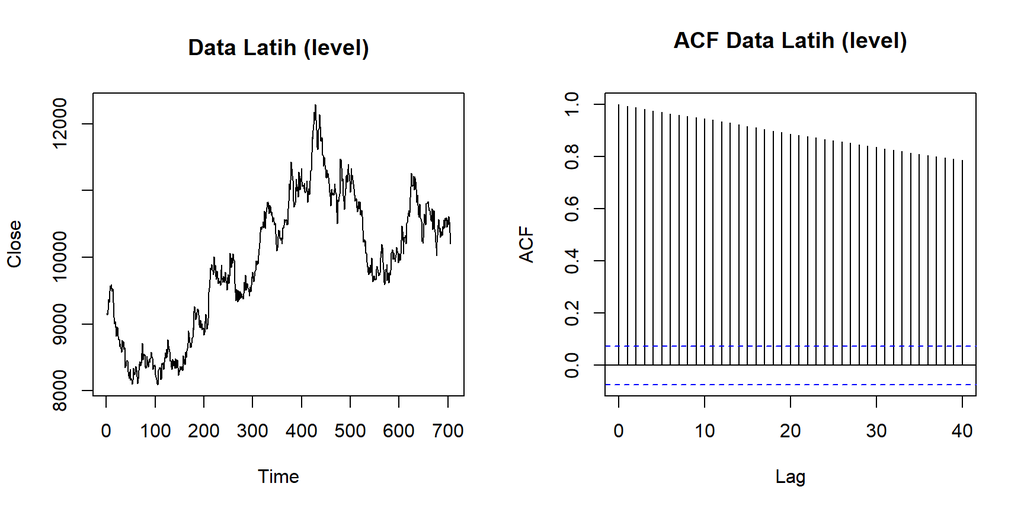

```r
par(mfrow = c(1, 2))
ts.plot(train, main = "Data Latih (level)", ylab = "Close")
acf(train, lag.max = 40, main = "ACF Data Latih (level)")
```

```r
par(mfrow = c(1, 1))

adf_level <- adf.test(train)
adf_level
```

```
##
##  Augmented Dickey-Fuller Test
##
## data:  train
## Dickey-Fuller = -1.81, Lag order = 8, p-value = 0.66
## alternative hypothesis: stationary
```

Plot deret menunjukkan pergerakan naik-turun yang tidak kembali ke satu rataan tetap, dan ACF meluruh sangat lambat (*tails off slowly*). Uji ADF memberikan p-value = **0.6606**, sehingga pada $\alpha = 5\%$ $H_0$ **tidak** ditolak: data **tidak stasioner dalam rataan** dan perlu diferensiasi.

## Kestasioneran dalam Ragam (Box-Cox)

Kestasioneran ragam diperiksa dengan transformasi Box-Cox pada data latih. Ragam dianggap stasioner jika selang kepercayaan 95% bagi $\lambda$ **memuat angka 1** (artinya tidak perlu transformasi).

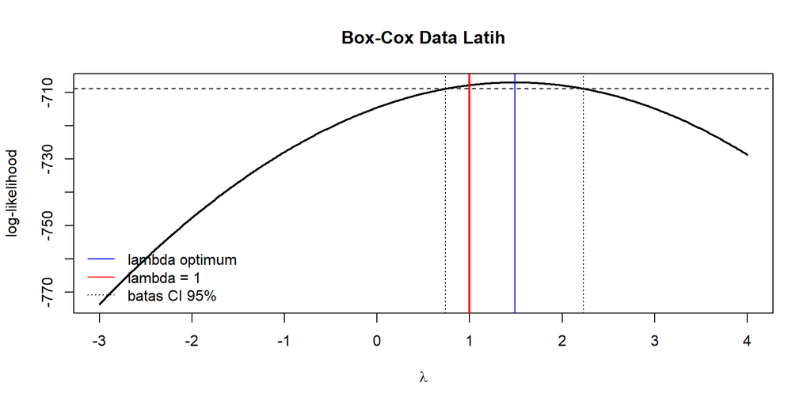

```r
bc <- MASS::boxcox(train ~ 1, lambda = seq(-3, 4, by = 0.01), plotit = FALSE)
batas <- max(bc$y) - qchisq(0.95, 1) / 2
dalam_ci <- bc$x[bc$y >= batas]

lambda_opt <- bc$x[which.max(bc$y)]
ci_bawah   <- min(dalam_ci)
ci_atas    <- max(dalam_ci)

plot(bc$x, bc$y, type = "l", lwd = 2, xlab = expression(lambda),
     ylab = "log-likelihood", main = "Box-Cox Data Latih")
abline(h = batas, lty = 2)
abline(v = c(ci_bawah, ci_atas), lty = 3)
abline(v = lambda_opt, col = "blue")
abline(v = 1, col = "red", lwd = 2)
legend("bottomleft", bty = "n", lty = c(1, 1, 3),
       col = c("blue", "red", "black"),
       legend = c("lambda optimum", "lambda = 1", "batas CI 95%"))
```

```r
data.frame(Lambda_optimum = lambda_opt, CI_bawah = ci_bawah, CI_atas = ci_atas,
           Memuat_1 = (ci_bawah <= 1 & ci_atas >= 1))
```

```
##   Lambda_optimum CI_bawah CI_atas Memuat_1
## 1           1.49     0.74    2.23     TRUE
```

Nilai $\lambda$ optimum = **1.49** dengan selang kepercayaan 95% **[0.74; 2.23]**, yang **memuat angka 1**, sehingga ragam data latih dinilai stasioner dan **tidak diperlukan transformasi**.

# Penanganan Ketidakstasioneran

Karena data tidak stasioner dalam rataan, dilakukan **diferensiasi orde 1** ($d = 1$). Transformasi tidak dilakukan karena ragam sudah stasioner (tahap sebelumnya).

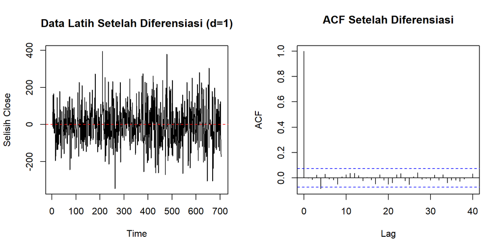

```r
train_d1 <- diff(train)

par(mfrow = c(1, 2))
ts.plot(train_d1, main = "Data Latih Setelah Diferensiasi (d=1)", ylab = "Selisih Close")
abline(h = 0, col = "red", lty = 2)
acf(train_d1, lag.max = 40, main = "ACF Setelah Diferensiasi")
```

```r
par(mfrow = c(1, 1))

adf_d1 <- adf.test(train_d1)
adf_d1
```

```
##
##  Augmented Dickey-Fuller Test
##
## data:  train_d1
## Dickey-Fuller = -9.35, Lag order = 8, p-value = 0.01
## alternative hypothesis: stationary
```

Setelah diferensiasi, data berfluktuasi di sekitar nol dan ACF tidak lagi meluruh lambat. Uji ADF memberikan p-value = **0.01** (< 0,05), sehingga data hasil diferensiasi **stasioner dalam rataan**. Orde diferensiasi yang dipakai: **d = 1**.

# Identifikasi Model Potensial

Identifikasi dilakukan pada data hasil diferensiasi melalui ACF, PACF, dan EACF.

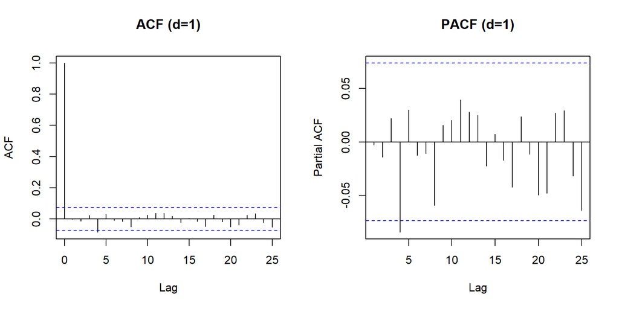

```r
par(mfrow = c(1, 2))
acf(train_d1,  lag.max = 25, main = "ACF (d=1)")
pacf(train_d1, lag.max = 25, main = "PACF (d=1)")
```

```r
par(mfrow = c(1, 1))
```

```r
TSA::eacf(train_d1)
```

```
## AR/MA
##   0 1 2 3 4 5 6 7 8 9 10 11 12 13
## 0 o o o x o o o o o o o  o  o  o
## 1 x o o o o o o o o o o  o  o  o
## 2 x x o o o o o o o o o  o  o  o
## 3 x x x o o o o o o o o  o  o  o
## 4 x o x x o o o o o o o  o  o  o
## 5 x o o x x o o o o o o  o  o  o
## 6 x o o x x o o o o o o  o  o  o
## 7 x x x x x o x o o o o  o  o  o
```

```r
batas_acf <- qnorm(0.975) / sqrt(length(train_d1))
r_acf  <- acf(train_d1,  lag.max = 25, plot = FALSE)$acf[-1]
r_pacf <- pacf(train_d1, lag.max = 25, plot = FALSE)$acf

lag_acf  <- which(abs(r_acf)  > batas_acf)
lag_pacf <- which(abs(r_pacf) > batas_acf)
```

Batas signifikansi ±0.074. Dari 25 lag yang diperiksa, lag ACF yang melewati batas: **4**; lag PACF yang melewati batas: **4**. Dengan taraf 5%, sekitar 1 dari 20 lag memang diharapkan melewati batas hanya karena kebetulan, sehingga satu-dua lag yang tipis melewati batas belum tentu mencerminkan struktur AR/MA yang nyata. Pola EACF juga didominasi simbol “o” (segitiga nol dimulai dari AR(0), MA(0)).

Artinya data hasil diferensiasi **hampir menyerupai *white noise*** , dan model paling sederhana, **ARIMA(0,1,0)**, menjadi kandidat utama. Agar kesimpulan ini diuji dan bukan hanya diasumsikan, kandidat lain di sekitarnya juga dibandingkan: ARIMA(1,1,0), ARIMA(0,1,1), ARIMA(1,1,1), ARIMA(2,1,0), ARIMA(0,1,2), serta ARIMA(0,1,0) dengan *drift*.

# Pendugaan Parameter, Signifikansi, dan AIC

Setiap koefisien diuji dengan uji-z ($H_0$: koefisien = 0), lalu model dibandingkan berdasarkan AIC (semakin kecil semakin baik).

```r
ringkas <- function(m, nama) {
  k <- length(coef(m))
  if (k > 0) {
    p <- 2 * pnorm(-abs(coef(m) / sqrt(diag(vcov(m)))))
    maks_p <- max(p); sig <- all(p < 0.05)
  } else {
    maks_p <- NA; sig <- NA
  }
  data.frame(Model = nama, Jumlah_parameter = k, AIC = m$aic, BIC = m$bic,
             Maks_p_value = maks_p, Semua_signifikan = sig)
}

orde_kandidat <- list(c(0,1,0), c(1,1,0), c(0,1,1), c(1,1,1), c(2,1,0), c(0,1,2))
fits <- lapply(orde_kandidat, function(o) Arima(train, order = o, method = "ML"))
nama <- sapply(orde_kandidat, function(o) sprintf("ARIMA(%d,%d,%d)", o[1], o[2], o[3]))
names(fits) <- nama

fits[["ARIMA(0,1,0) + drift"]] <- Arima(train, order = c(0,1,0), include.drift = TRUE, method = "ML")

tabel_model <- do.call(rbind, lapply(names(fits), function(nm) ringkas(fits[[nm]], nm)))
tabel_model <- tabel_model[order(tabel_model$AIC), ]
rownames(tabel_model) <- NULL
kable(tabel_model, digits = 3, caption = "Perbandingan model kandidat (diurutkan menurut AIC)")
```

Perbandingan model kandidat (diurutkan menurut AIC)

| Model | Jumlah_parameter | AIC | BIC | Maks_p_value | Semua_signifikan |
| --- | --- | --- | --- | --- | --- |
| ARIMA(0,1,0) | 0 | 8604.9 | 8609.4 | NA | NA |
| ARIMA(0,1,0) + drift | 1 | 8606.7 | 8615.9 | 0.717 | FALSE |
| ARIMA(0,1,1) | 1 | 8606.9 | 8616.0 | 0.940 | FALSE |
| ARIMA(1,1,0) | 1 | 8606.9 | 8616.0 | 0.941 | FALSE |
| ARIMA(0,1,2) | 2 | 8608.7 | 8622.4 | 0.955 | FALSE |
| ARIMA(2,1,0) | 2 | 8608.7 | 8622.4 | 0.939 | FALSE |
| ARIMA(1,1,1) | 2 | 8608.9 | 8622.5 | NaN | NA |

Aturan pemilihan: model terbaik adalah yang **AIC-nya terkecil di antara model yang seluruh parameternya signifikan** (model tanpa parameter otomatis memenuhi).

```r
layak <- is.na(tabel_model$Semua_signifikan) | tabel_model$Semua_signifikan
model_terbaik <- tabel_model$Model[layak][which.min(tabel_model$AIC[layak])]
fit_terbaik   <- fits[[model_terbaik]]
orde_terbaik  <- arimaorder(fit_terbaik)   # p, d, q
model_terbaik
```

```
## [1] "ARIMA(0,1,0)"
```

Model terpilih: **ARIMA(0,1,0)**. Pada model kandidat yang memiliki parameter (AR atau MA), nilai p-value terbesarnya jauh di atas 0,05 sehingga penambahan suku AR/MA tidak memberi kontribusi nyata, sedangkan AIC-nya pun tidak lebih baik. Model dengan *drift* juga tidak dipilih karena AIC lebih besar dan koefisien drift tidak signifikan (p = 0.717).

```r
fit_terbaik
```

```
## Series: train
## ARIMA(0,1,0)
##
## sigma^2 = 11874:  log likelihood = -4301.4
## AIC=8604.9   AICc=8604.9   BIC=8609.4
```

# Analisis Sisaan

Asumsi yang diperiksa: sisaan berdistribusi normal, tidak berautokorelasi (*white noise*), bernilai tengah nol, dan berragam homogen.

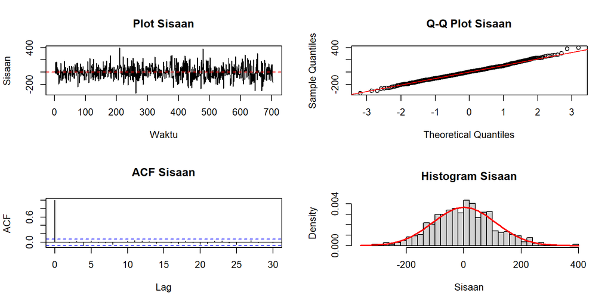

```r
res <- as.numeric(residuals(fit_terbaik))
par(mfrow = c(2, 2))
plot(res, type = "l", main = "Plot Sisaan", ylab = "Sisaan", xlab = "Waktu"); abline(h = 0, col = "red", lty = 2)
qqnorm(res, main = "Q-Q Plot Sisaan"); qqline(res, col = "red")
acf(res, lag.max = 30, main = "ACF Sisaan")
hist(res, breaks = 30, freq = FALSE, main = "Histogram Sisaan", xlab = "Sisaan")
curve(dnorm(x, mean(res), sd(res)), add = TRUE, col = "red", lwd = 2)
```

```r
par(mfrow = c(1, 1))
```

```r
k_par <- length(coef(fit_terbaik))   # derajat kebebasan yang dikoreksi
lb   <- Box.test(res,   lag = 20, type = "Ljung-Box", fitdf = k_par)
arch <- Box.test(res^2, lag = 20, type = "Ljung-Box")
sw   <- shapiro.test(res)
jb   <- jarque.bera.test(res)
tt   <- t.test(res, mu = 0)

uji_sisaan <- data.frame(
  Asumsi = c("Normalitas", "Normalitas", "Tidak ada autokorelasi",
             "Nilai tengah nol", "Ragam homogen (tanpa efek ARCH)"),
  Uji    = c("Shapiro-Wilk", "Jarque-Bera", "Ljung-Box (lag 20)",
             "t-test (mu = 0)", "Ljung-Box pada sisaan kuadrat (lag 20)"),
  p_value = c(sw$p.value, jb$p.value, lb$p.value, tt$p.value, arch$p.value)
)
uji_sisaan$Keputusan <- ifelse(uji_sisaan$p_value > 0.05, "Asumsi terpenuhi", "Asumsi dilanggar")
kable(uji_sisaan, digits = 4, caption = "Uji asumsi sisaan (H0 = asumsi terpenuhi, alpha = 5%)")
```

Uji asumsi sisaan (H0 = asumsi terpenuhi, alpha = 5%)

| Asumsi | Uji | p_value | Keputusan |
| --- | --- | --- | --- |
| Normalitas | Shapiro-Wilk | 0.4393 | Asumsi terpenuhi |
| Normalitas | Jarque-Bera | 0.1446 | Asumsi terpenuhi |
| Tidak ada autokorelasi | Ljung-Box (lag 20) | 0.7357 | Asumsi terpenuhi |
| Nilai tengah nol | t-test (mu = 0) | 0.7148 | Asumsi terpenuhi |
| Ragam homogen (tanpa efek ARCH) | Ljung-Box pada sisaan kuadrat (lag 20) | 0.4068 | Asumsi terpenuhi |

**Kesimpulan sisaan.** Dari lima uji, **5 dari 5** menyatakan asumsi terpenuhi. Sisaan tidak berautokorelasi, bernilai tengah nol, menyebar normal, dan tidak menunjukkan efek ARCH (ragam homogen).

# Overfitting

Model terpilih diuji dengan menambahkan **satu** parameter AR atau MA. Jika parameter tambahan tidak signifikan dan AIC tidak membaik, model awal tidak kekurangan suku (tidak *underfit*) dan tidak perlu diperumit.

```r
p0 <- orde_terbaik[1]; d0 <- orde_terbaik[2]; q0 <- orde_terbaik[3]

cek_over <- function(o, suku) {
  m <- Arima(train, order = o, method = "ML")
  p <- 2 * pnorm(-abs(coef(m) / sqrt(diag(vcov(m)))))
  data.frame(Model = sprintf("ARIMA(%d,%d,%d)", o[1], o[2], o[3]),
             Parameter_tambahan = suku,
             Estimasi = unname(coef(m)[suku]),
             p_value  = unname(p[suku]),
             AIC = m$aic)
}

tabel_over <- rbind(
  cek_over(c(p0 + 1, d0, q0), paste0("ar", p0 + 1)),
  cek_over(c(p0, d0, q0 + 1), paste0("ma", q0 + 1))
)
tabel_over$AIC_model_terbaik <- fit_terbaik$aic
tabel_over$Kesimpulan <- ifelse(tabel_over$p_value > 0.05 & tabel_over$AIC >= tabel_over$AIC_model_terbaik,
                                "Tidak perlu (tidak signifikan, AIC tidak membaik)",
                                "Perlu dipertimbangkan")
kable(tabel_over, digits = 4, caption = "Uji overfitting")
```

Uji overfitting

| Model | Parameter_tambahan | Estimasi | p_value | AIC | AIC_model_terbaik | Kesimpulan |
| --- | --- | --- | --- | --- | --- | --- |
| ARIMA(1,1,0) | ar1 | -0.0028 | 0.9412 | 8606.9 | 8604.9 | Tidak perlu (tidak signifikan, AIC tidak membaik) |
| ARIMA(0,1,1) | ma1 | -0.0029 | 0.9404 | 8606.9 | 8604.9 | Tidak perlu (tidak signifikan, AIC tidak membaik) |

Parameter tambahan pada kedua model *overfitting* **tidak signifikan** dan AIC-nya tidak lebih kecil dari model terpilih, sehingga **ARIMA(0,1,0) dipertahankan sebagai model akhir**.

# Peramalan

Peramalan dilakukan sepanjang data uji (**79 hari bursa**) dan dibandingkan dengan nilai aktual.

```r
h  <- length(test)
fc <- forecast(fit_terbaik, h = h, level = c(80, 95))

galat <- test - as.numeric(fc$mean)
akurasi <- data.frame(
  RMSE = sqrt(mean(galat^2)),
  MAE  = mean(abs(galat)),
  MAPE_persen = mean(abs(galat / test)) * 100,
  Cakupan_PI95_persen = mean(test >= fc$lower[, 2] & test <= fc$upper[, 2]) * 100
)
kable(akurasi, digits = 3, caption = "Akurasi peramalan pada data uji")
```

Akurasi peramalan pada data uji

| RMSE | MAE | MAPE_persen | Cakupan_PI95_persen |
| --- | --- | --- | --- |
| 278.33 | 219.1 | 2.159 | 100 |

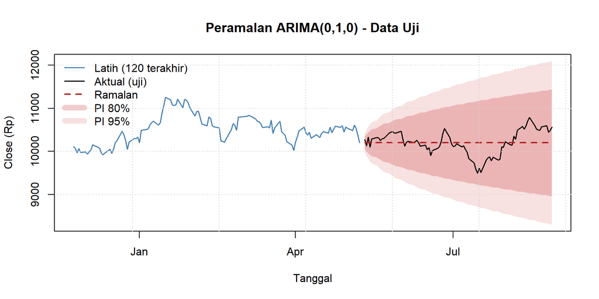

```r
tail_idx <- (n_train - 119):n_train
plot(range(c(train_df$Date[tail_idx], test_df$Date)),
     range(c(train_df$Close[tail_idx], test, fc$lower, fc$upper)),
     type = "n", xlab = "Tanggal", ylab = "Close (Rp)",
     main = paste("Peramalan", model_terbaik, "- Data Uji"))
polygon(c(test_df$Date, rev(test_df$Date)), c(fc$lower[, 2], rev(fc$upper[, 2])),
        col = rgb(0.8, 0.2, 0.2, 0.15), border = NA)
polygon(c(test_df$Date, rev(test_df$Date)), c(fc$lower[, 1], rev(fc$upper[, 1])),
        col = rgb(0.8, 0.2, 0.2, 0.25), border = NA)
lines(train_df$Date[tail_idx], train_df$Close[tail_idx], col = "steelblue", lwd = 1.5)
lines(test_df$Date, test, col = "black", lwd = 1.5)
lines(test_df$Date, as.numeric(fc$mean), col = "firebrick", lwd = 2, lty = 2)
legend("topleft", bty = "n", lwd = c(1.5, 1.5, 2, 8, 8), lty = c(1, 1, 2, 1, 1),
       col = c("steelblue", "black", "firebrick", rgb(0.8, 0.2, 0.2, 0.25), rgb(0.8, 0.2, 0.2, 0.15)),
       legend = c("Latih (120 terakhir)", "Aktual (uji)", "Ramalan", "PI 80%", "PI 95%"))
grid()
```

**Interpretasi.** Pada data uji, RMSE = **278.3** dan MAPE = **2.16%**. Selang prediksi 95% menutup **100%** nilai aktual. Karena model terpilih adalah ARIMA(0,1,0) tanpa drift, ramalan tepat sama dengan nilai terakhir data latih (garis datar), atau setara dengan metode *naive*. Selang prediksi melebar seiring bertambahnya horizon karena ketidakpastian menumpuk.

# Kesimpulan

```r
data.frame(
  Tahap = c("Stasioner rataan", "Stasioner ragam", "Diferensiasi", "Model terpilih",
            "Sisaan", "Overfitting", "Akurasi forecast"),
  Hasil = c(
    paste0("ADF level p = ", round(adf_level$p.value, 3), ifelse(adf_level$p.value < 0.05, " (stasioner)", " (tidak stasioner)")),
    paste0("Box-Cox CI [", round(ci_bawah, 2), "; ", round(ci_atas, 2), "]", ifelse(ci_bawah <= 1 & ci_atas >= 1, " memuat 1", " tidak memuat 1")),
    paste0("d = 1, ADF p = ", format(adf_d1$p.value, digits = 2)),
    model_terbaik,
    paste0(sum(uji_sisaan$p_value > 0.05), " dari 5 uji asumsi terpenuhi"),
    ifelse(all(tabel_over$p_value > 0.05), "Parameter tambahan tidak signifikan", "Ada parameter tambahan signifikan"),
    paste0("RMSE ", round(akurasi$RMSE, 1), "; MAPE ", round(akurasi$MAPE_persen, 2), "%")
  )
) |> kable(caption = "Ringkasan seluruh tahapan")
```

Ringkasan seluruh tahapan

| Tahap | Hasil |
| --- | --- |
| Stasioner rataan | ADF level p = 0.661 (tidak stasioner) |
| Stasioner ragam | Box-Cox CI [0.74; 2.23] memuat 1 |
| Diferensiasi | d = 1, ADF p = 0.01 |
| Model terpilih | ARIMA(0,1,0) |
| Sisaan | 5 dari 5 uji asumsi terpenuhi |
| Overfitting | Parameter tambahan tidak signifikan |
| Akurasi forecast | RMSE 278.3; MAPE 2.16% |

Setelah diferensiasi, harga penutupan BBCA nyaris tidak menyisakan struktur autokorelasi yang bisa dimodelkan, sehingga model yang didukung data adalah *random walk* ARIMA(0,1,0). Ini bukan kegagalan pemodelan, melainkan temuan: perubahan harian harga saham sulit diprediksi dari riwayatnya sendiri. Konsekuensinya, ramalan ARIMA berfungsi sebagai **pembanding dasar (*baseline*)** dan hanya andal untuk arah sebaran ketidakpastian, bukan untuk menebak pergerakan harga.